# OpenCaseStudies - Opoids

Open Case Study Team

# data preparation

```r
library(readxl)
library(devtools)
library(usethis)
library(tidyverse)
library(openintro)
library(arcos)
library(ggiraph)
library(ggpubr)
library(ggfortify)
library(ggpol)
library(lme4)
library(formattable)
library(reshape2)
```

Question: How did opioid prescription amount differ by region over time around the US from 2006-2013?

Description: We will evaluate prescription amount of opioid pain medication across states/counties from 2006-2013. We will investigate how rural and urban areas differ for prescription rates.

Analysis of patient opioid prescription data from a national electronic health record vendor during 2014 - 2017 found that the percentage of patients prescribed an opioid was higher in rural than in urban areas. Significant decreases in opioid prescribing occurred across all urban-rural categories after the March 2016 release of the CDC Guideline for Prescribing Opioids for Chronic Pain.

Statistics objectives: Linear regression analysis to evaluate the association of urbanization/population density and opioid prescription rates over time.

# population data

```r
head(read.csv('data/2010.csv', header=TRUE) )
```

```
##           GEO_ID                     NAME     B01003_001E
## 1             id     Geographic Area Name Estimate!!Total
## 2 0500000US08025 Crowley County, Colorado            5897
## 3 0500000US08029   Delta County, Colorado           30533
## 4 0500000US08031  Denver County, Colorado          578087
## 5 0500000US08033 Dolores County, Colorado            2027
## 6 0500000US08035 Douglas County, Colorado          273440
##              B01003_001M
## 1 Margin of Error!!Total
## 2                  *****
## 3                  *****
## 4                  *****
## 5                  *****
## 6                  *****
```

Here I get the population for each county from https://data.census.gov/cedsci/table?q=population&hidePreview=true&tid=ACSDT5Y2010.B01003&vintage=2018&g=0100000US.050000

[figure not shown]

The ACS conducts recurring surveys every few months that are used for different periods. The 1-year survey does not use much data, and the number of observations that are reliably reported is resultantly restricted because of the number of poor estimates generated for a portion of the country. 5 year data should suffice!

```r
read_pop <- function(file){
  read.csv( file, header=TRUE) %>% slice(2:n()) %>%
  mutate(FIPS = str_sub(GEO_ID, -5,-1), POP = as.numeric(as.character(B01003_001E))  ) %>%
  select(FIPS, POP)
}

pop2010 <- read_pop('data/2010.csv')
pop2011 <- read_pop('data/2011.csv')
pop2012 <- read_pop('data/2012.csv')
pop2013 <- read_pop('data/2013.csv')
pop2014 <- read_pop('data/2014.csv')
```

## Washinton Post

```r
dfCSSraw <- read_excel("data/PctUrbanRural_County.xls")
```

`dfcss` is used to save urban and rural in 2010 and calculate the total number

1. 1 sq meters = 3.8610215854781257e-7 sq miles
2. Today, “urban areas” consist of two types of geographies:

“Urbanized Areas” have a population of 50,000 or more. “Urban Clusters” have a population of at least 2,500 and less than 50,000.

```r
dfCSSraw$COUNTYNAME <- gsub('LaSalle','La Salle', dfCSSraw$COUNTYNAME)
dfCSSraw$COUNTYNAME <- gsub('Do??a Ana','Dona Ana', dfCSSraw$COUNTYNAME)


dfcss <- dfCSSraw %>% select(STATE,COUNTY,STATENAME,COUNTYNAME,
  POP_COU,AREA_COU, POP_URBAN,POPPCT_URBAN,POP_RURAL,POPPCT_RURAL) %>%
  filter(STATENAME !='Puerto Rico') %>%
  mutate(STATENAME2 = state2abbr(STATENAME), FIPS= paste(STATE,COUNTY,sep=""))
```

```r
L <- list( pop2010[, c('FIPS','POP')], pop2011[, c('FIPS','POP')],
           pop2012[, c('FIPS','POP')], pop2013[, c('FIPS','POP')],
           pop2014[, c('FIPS','POP')], dfcss)

DENS<- function(x){return(x/( dfcss$AREA_COU*0.0000003861)) }
UB <- function(x){ return(ifelse( x >= 50000,'U','R')) }


dfCSS<-Reduce(function(x,y) left_join(x, y,
                      by = colnames(x)[1]), L)%>%
  mutate(FIPS = str_remove(FIPS, "^0+"),
        DENS10 = DENS(POP.x), UB10 = UB(POP.x),
        DENS11 = DENS(POP.y), UB11 = UB(POP.y),
        DENS12 = DENS(POP.x.x), UB12 = UB(POP.x.x),
        DENS13 = DENS(POP.y.y), UB13 = UB(POP.y.y),
        DENS14 = DENS(POP), UB14 = UB(POP))  %>%
  select(FIPS,STATE= STATENAME2,COUNTY=COUNTYNAME,
         DENS10, UB10,DENS11, UB11, DENS12, UB12,DENS13,
         UB13,DENS14, UB14 )%>% drop_na()

summary(dfCSS)
```

```
##      FIPS              STATE              COUNTY              DENS10
##  Length:3142        Length:3142        Length:3142        Min.   :    0.077
##  Class :character   Class :character   Class :character   1st Qu.:   14.778
##  Mode  :character   Mode  :character   Mode  :character   Median :   40.071
##                                                           Mean   :  228.951
##                                                           3rd Qu.:  117.632
##                                                           Max.   :22304.787
##      UB10               DENS11              UB11               DENS12
##  Length:3142        Min.   :    0.073   Length:3142        Min.   :    0.084
##  Class :character   1st Qu.:   14.764   Class :character   1st Qu.:   14.736
##  Mode  :character   Median :   40.182   Mode  :character   Median :   40.228
##                     Mean   :  230.678                      Mean   :  232.281
##                     3rd Qu.:  119.040                      3rd Qu.:  119.898
##                     Max.   :22515.627                      Max.   :22683.568
##      UB12               DENS13              UB13               DENS14
##  Length:3142        Min.   :    0.091   Length:3142        Min.   :    0.093
##  Class :character   1st Qu.:   14.744   Class :character   1st Qu.:   14.732
##  Mode  :character   Median :   40.366   Mode  :character   Median :   40.480
##                     Mean   :  233.801                      Mean   :  235.354
##                     3rd Qu.:  120.278                      3rd Qu.:  121.357
##                     Max.   :22872.593                      Max.   :23064.356
##      UB14
##  Length:3142
##  Class :character
##  Mode  :character
##
##
##
```

### How does the density changes over years?

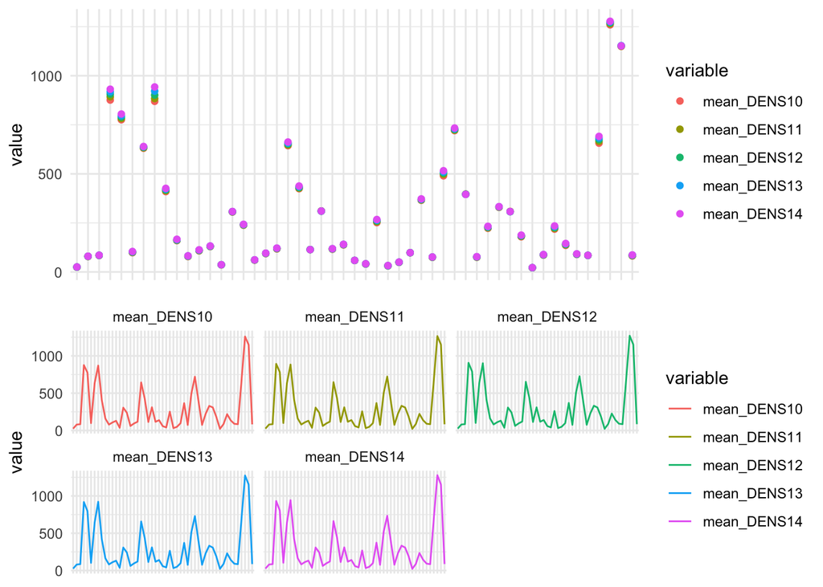

```r
dfCSS1 <- dfCSS  %>% group_by(STATE ) %>%
     summarise( mean_DENS10 = mean(DENS10),
                mean_DENS11 = mean(DENS11),
                mean_DENS12 = mean(DENS12),
                mean_DENS13 = mean(DENS13),
                mean_DENS14 = mean(DENS14))

dfCSS_m <- melt(dfCSS1 , id.vars="STATE")

 #Everything on the same plot
m1 <- ggplot(dfCSS_m , aes(STATE, value, col=variable,group = variable)) +
  geom_point() +
  #stat_smooth() +
  theme_minimal()+
  theme(axis.title.x=element_blank(),
        axis.text.x=element_blank())

# Separate plots
m2 <- ggplot(dfCSS_m , aes(STATE, value, col=variable,group = variable)) +
  geom_line() +
  facet_wrap(~variable)+
  theme_minimal()+
  theme(axis.title.x=element_blank(),
        axis.text.x=element_blank())

ggarrange(m1, m2, nrow =2)
```

The density in these states doesn’t change too much from 2010 to 2014.